# Task 4

Evgeny Bakin

2023-11-05

# Сравнение вероятностей наступления события в двухгрупповом исследовании

## 1. Модель пациента

```r
p_R <- 0.1 # Истинная вероятность выздоровления для референса (в ГЕНЕРАЛЬНОЙ СОВОКУПНОСТИ)

p_T <- 0.2 # Истинная вероятность выздоровления для теста (в ГЕНЕРАЛЬНОЙ СОВОКУПНОСТИ)

true_OR <- (p_T/(1-p_T))/(p_R/(1-p_R)) # Истинное отношение шансов
```

## 2. Генерация однократной выборки

```r
sample_size <- 100 # Количество пациентов в каждой из групп

df_trial <- data.frame(
  arm = rep(c('R', 'T'), each = sample_size),
  patient_ID = rep(1:sample_size, 2),
  recovery_status = c(sample(c(1,0), sample_size, replace = TRUE, prob = c(p_R, 1 - p_R)),
                      sample(c(1,0), sample_size, replace = TRUE, prob = c(p_T, 1 - p_T)))
)
```

## 3. Построение ДИ для разницы вероятностей

```r
df_prop <- df_trial %>%
  group_by(arm) %>% # Группировка типу интервенции (тест/референс)
  dplyr::summarise(x = sum(recovery_status), # Подсчет числа положительных исходов (единиц)
                   n = n()) %>% # Подсчет общего числа пациентов в группе
  ungroup() %>%
  dplyr::summarise(X = list(x), N = list(n)) %>% # Соединение все x и n в отдельные вектора
  rowwise() %>%
  mutate(tst = list(broom::tidy(prop.test(X, N)))) %>% # Вычисление ДИ на разницу пропорций
  unnest(tst) %>% # Раскладка результатов prop.test по столбцам
  mutate(catch = ifelse(conf.low < p_R-p_T & p_R-p_T < conf.high, "Catch", "Miss"))

print(df_prop)
```

```
## # A tibble: 1 × 12
##   X     N     estimate1 estimate2 statistic p.value parameter conf.low conf.high
##   <lis> <lis>     <dbl>     <dbl>     <dbl>   <dbl>     <dbl>    <dbl>     <dbl>
## 1 <dbl> <int>      0.12      0.25      4.78  0.0289         1   -0.246   -0.0139
## # ℹ 3 more variables: method <chr>, alternative <chr>, catch <chr>
```

## ЗАДАНИЕ №1

- Повторить этот эксперимент 1000 раз, каждый раз фиксирую факт накрытия истинной разницы в вероятностях (p_R-p_T).
- Оценить полученную вероятность накрытия с заданной по умолчанию (0.95).
- Построить гистограмму точечной оценки разницы вероятностей (estimate1-estimae2) и подумать о ее распределении.
- Проверить, корректно ли работает методика построения ДИ, реализованная в prop.test, при различных значениях p_R и p_T.

Для удобства оформил создание сэмпла в одтельную функцию:

```r
sample_generate <- function(sample_size = 100, p_R = 0.1, p_T = 0.2) {
  true_OR <- (p_T/(1-p_T))/(p_R/(1-p_R)) # Истинное отношение шансов
  data.frame(
  arm = rep(c('R', 'T'), each = sample_size),
  patient_ID = rep(1:sample_size, 2),
  recovery_status = c(sample(c(1,0), sample_size, replace = TRUE, prob = c(p_R, 1 - p_R)),
                      sample(c(1,0), sample_size, replace = TRUE, prob = c(p_T, 1 - p_T)))
  )
}
```

Так же создал функцию для проведения эксперимента (наверное можно было проще как-то сделать)

```r
do_experiment <- function(p_R = 0.1, p_T = 0.2) {
  df = sample_generate(p_R = p_T, p_T = p_T)
  df %>%
  group_by(arm) %>% # Группировка типу интервенции (тест/референс)
  dplyr::summarise(x = sum(recovery_status), # Подсчет числа положительных исходов (единиц)
                   n = n()) %>% # Подсчет общего числа пациентов в группе
  ungroup() %>%
  dplyr::summarise(X = list(x), N = list(n)) %>% # Соединение все x и n в отдельные вектора
  rowwise() %>%
  mutate(tst = list(broom::tidy(prop.test(X, N)))) %>% # Вычисление ДИ на разницу пропорций
  unnest(tst) %>% # Раскладка результатов prop.test по столбцам
  mutate(catch = ifelse(conf.low < p_R-p_T & p_R-p_T < conf.high, "Catch", "Miss"))
}
```

Проведем 1000 экспериментов с заданными значениями (p_R = 0,1, p_T = 0,2)

```r
num_repeats = 1000
result_df <- lapply(1:num_repeats, function(i) do_experiment(p_R = 0.1, p_T = 0.2)) %>% bind_rows()
result_df %>% head()
```

```
## # A tibble: 6 × 12
##   X     N     estimate1 estimate2 statistic p.value parameter conf.low conf.high
##   <lis> <lis>     <dbl>     <dbl>     <dbl>   <dbl>     <dbl>    <dbl>     <dbl>
## 1 <dbl> <int>      0.21      0.19    0.0312   0.860         1  -0.101     0.141
## 2 <dbl> <int>      0.2       0.24    0.262    0.609         1  -0.165     0.0847
## 3 <dbl> <int>      0.19      0.19    0        1             1  -0.109     0.109
## 4 <dbl> <int>      0.27      0.2     1.00     0.317         1  -0.0571    0.197
## 5 <dbl> <int>      0.2       0.23    0.119    0.731         1  -0.154     0.0938
## 6 <dbl> <int>      0.18      0.15    0.145    0.703         1  -0.0828    0.143
## # ℹ 3 more variables: method <chr>, alternative <chr>, catch <chr>
```

Посчитаем количество накрытых и ненакрытих доверительными интервалами значений и их пропорцию.

```r
result_df %>%
  group_by(catch) %>%
  summarize(n = n(),
            p = n / nrow(result_df))
```

```
## # A tibble: 2 × 3
##   catch     n     p
##   <chr> <int> <dbl>
## 1 Catch   611 0.611
## 2 Miss    389 0.389
```

Процент накрытых не согласуется с заявленной вероятностью 95%

Строим гистограмму точечной оценки разницы вероятностей.

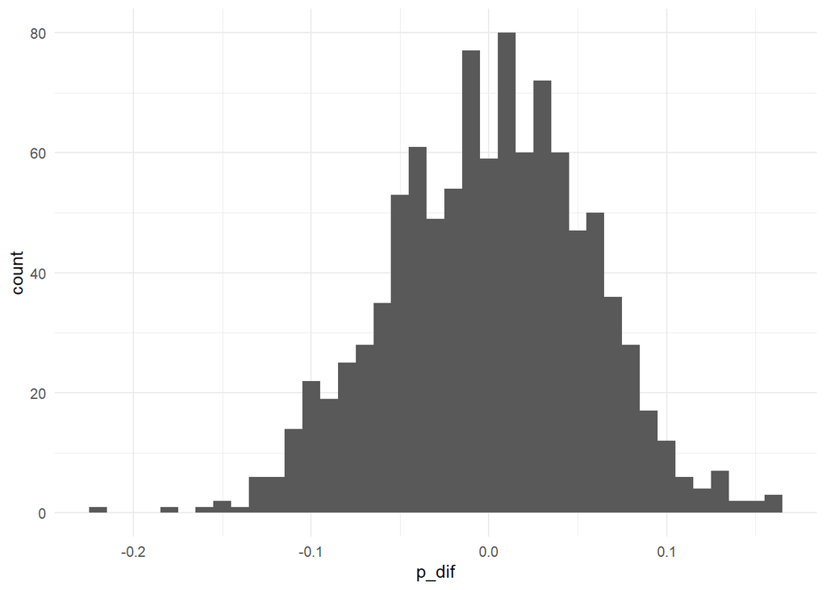

```r
result_df <- result_df %>%
  mutate(p_dif = estimate1 - estimate2)

result_df %>%
  ggplot(fill="blue") +
  aes(p_dif) +
  geom_histogram(binwidth = 0.01)+
  theme_minimal()
```

Выглядит как нормальное, но лучше проверить.

```r
shapiro.test(result_df$p_dif)
```

```
##
##  Shapiro-Wilk normality test
##
## data:  result_df$p_dif
## W = 0.99501, p-value = 0.002274
```

Распределение уже не кажется нормальным.

```r
library(goft)
cauchy_test(result_df$p_dif)
```

```
##
##  Test for the Cauchy distribution based on a transformation to
##  exponential data
##
## data:  result_df$p_dif
## T = 19.802, p-value < 2.2e-16
```

Похоже, что это не распределение Коши.

Теперь поменяем p_R = 0.1, p_T = 0.15

```r
num_repeats = 1000
result_df <- lapply(1:num_repeats, function(i) do_experiment(p_R = 0.1, p_T = 0.15)) %>% bind_rows()

result_df %>%
  group_by(catch) %>%
  summarize(n = n(),
            p = n / nrow(result_df))
```

```
## # A tibble: 2 × 3
##   catch     n     p
##   <chr> <int> <dbl>
## 1 Catch   866 0.866
## 2 Miss    134 0.134
```

При уменьшении разности вероятностей меняется процент накрытых доверительными интервалами.

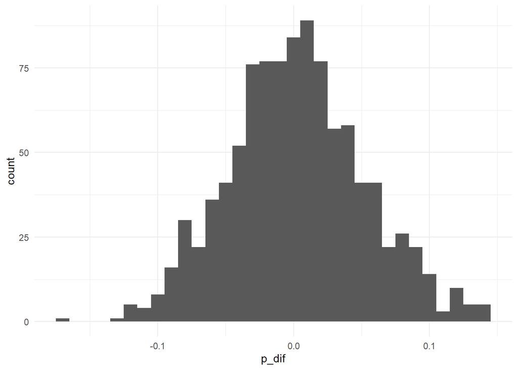

```r
result_df %>%
  mutate(p_dif = estimate1 - estimate2) %>%
  ggplot(fill="blue") +
  aes(p_dif) +
  geom_histogram(binwidth = 0.01)+
  theme_minimal()
```

Теперь поменяем p_R = 0.1, p_T = 0.9

```r
num_repeats = 1000
result_df <- lapply(1:num_repeats, function(i) do_experiment(p_R = 0.1, p_T = 0.9)) %>% bind_rows()
result_df %>%
  group_by(catch) %>%
  summarize(n = n(),
            p = n / nrow(result_df))
```

```
## # A tibble: 1 × 3
##   catch     n     p
##   <chr> <int> <dbl>
## 1 Miss   1000     1
```

А почти максимальной разницу p_R и p_T, ненакрытие становится равно 100%.

Теперь поменяем p_R = 0.1, p_T = 0.4

```r
num_repeats = 1000
result_df <- lapply(1:num_repeats, function(i) do_experiment(p_R = 0.1, p_T = 0.4)) %>% bind_rows()
result_df %>%
  group_by(catch) %>%
  summarize(n = n(),
            p = n / nrow(result_df))
```

```
## # A tibble: 2 × 3
##   catch     n     p
##   <chr> <int> <dbl>
## 1 Catch    10  0.01
## 2 Miss    990  0.99
```

При значительной разницу p_R и p_T, вероятность накрытия опять другая.

```r
num_repeats = 1000
result_df <- lapply(1:num_repeats, function(i) do_experiment(p_R = 0.3, p_T = 0.4)) %>% bind_rows()
result_df %>%
  group_by(catch) %>%
  summarize(n = n(),
            p = n / nrow(result_df))
```

```
## # A tibble: 2 × 3
##   catch     n     p
##   <chr> <int> <dbl>
## 1 Catch   718 0.718
## 2 Miss    282 0.282
```

Вероятность накрытия имеет сложную зависимость от соотношения вероятностьей p_R и p_T.

## 4. Построение ДИ для отношения шансов

```r
df_OR <- df_trial %>%
  dplyr::summarise(broom::tidy(fisher.test(table(.$arm, .$recovery_status)))) %>%
  mutate(catch = ifelse(conf.low < true_OR & true_OR < conf.high, "Catch", "Miss"))

print(df_OR)
```

```
##   estimate    p.value conf.low conf.high                             method
## 1  2.43364 0.02794271 1.090469  5.702804 Fisher's Exact Test for Count Data
##   alternative catch
## 1   two.sided Catch
```

## ЗАДАНИЕ №2

- Повторить этот эксперимент 1000 раз, каждый раз фиксирую факт накрытия истинного отношения шансов (true_OR).
- Оценить полученную вероятность накрытия с заданной по умолчанию (0.95).
- Построить гистограмму точечной оценки отношения шансов (estimate) и подумать о ее распределении.
- Проверить, корректно ли работает методика построения ДИ, реализованная в fisher.test, при различных значениях p_R и p_T.

Создадим функцию для эксперимента

```r
do_experiment <- function(p_R = 0.1, p_T = 0.1) {
  df = sample_generate(p_R = p_R, p_T = p_T)
  df %>%
    dplyr::summarise(broom::tidy(fisher.test(table(.$arm, .$recovery_status)))) %>%
    mutate(catch = ifelse(conf.low < true_OR & true_OR < conf.high, "Catch", "Miss"))
}
```

Выполняем эксперимент 1000 раз (p_R = 0.1, p_T = 0.2)

```r
num_repeats = 1000
result_df <- lapply(1:num_repeats, function(i) do_experiment(p_R = 0.1, p_T = 0.2)) %>% bind_rows()
result_df %>% head()
```

```
##   estimate    p.value  conf.low conf.high                             method
## 1 2.361721 0.06521337 0.9539727  6.279556 Fisher's Exact Test for Count Data
## 2 1.584571 0.39282962 0.6262760  4.177027 Fisher's Exact Test for Count Data
## 3 2.968545 0.03998000 1.0433531  9.701256 Fisher's Exact Test for Count Data
## 4 2.708021 0.04840207 1.0060354  8.123839 Fisher's Exact Test for Count Data
## 5 1.652999 0.30826247 0.6838993  4.151395 Fisher's Exact Test for Count Data
## 6 2.345585 0.08562277 0.9026033  6.626409 Fisher's Exact Test for Count Data
##   alternative catch
## 1   two.sided Catch
## 2   two.sided Catch
## 3   two.sided Catch
## 4   two.sided Catch
## 5   two.sided Catch
## 6   two.sided Catch
```

```r
result_df %>%
  group_by(catch) %>%
  summarize(n = n(),
            p = n / nrow(result_df)*100)
```

```
## # A tibble: 2 × 3
##   catch     n     p
##   <chr> <int> <dbl>
## 1 Catch   968  96.8
## 2 Miss     32   3.2
```

Результат согласуется с заявленной вероятностью 95%

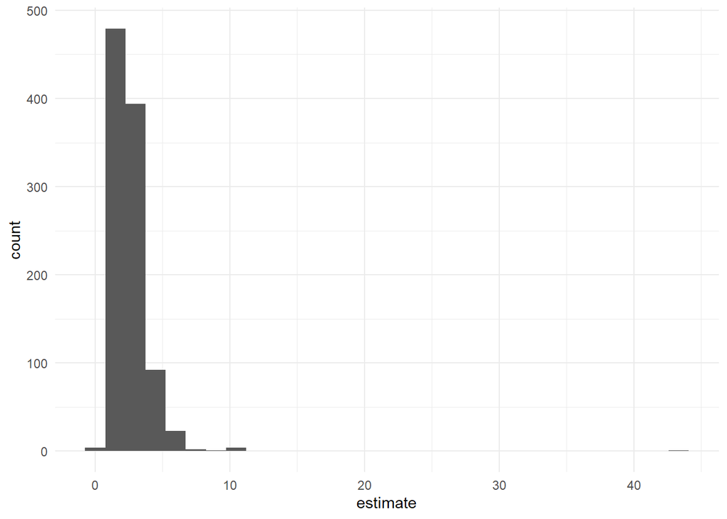

```r
result_df %>%
  ggplot(fill="blue") +
  aes(estimate) +
  geom_histogram()+
  theme_minimal()
```

Распределение не нормальное.

```r
lnorm_test(result_df$estimate)
```

```
##
##  Test for the lognormal distribution based on a transformation to
##  normality
##
## data:  result_df$estimate
## p-value = 4.796e-09
```

Это не логнормальное распределение (хотя похоже)

Выполняем эксперимент 1000 раз (p_R = 0.1, p_T = 0.15)

```r
num_repeats = 1000
result_df <- lapply(1:num_repeats, function(i) do_experiment(p_R = 0.1, p_T = 0.15)) %>% bind_rows()
result_df %>%
  group_by(catch) %>%
  summarize(n = n(),
            p = n / nrow(result_df)*100)
```

```
## # A tibble: 2 × 3
##   catch     n     p
##   <chr> <int> <dbl>
## 1 Catch   905  90.5
## 2 Miss     95   9.5
```

Результат ухудшился

```r
num_repeats = 1000
result_df <- lapply(1:num_repeats, function(i) do_experiment(p_R = 0.1, p_T = 0.15)) %>% bind_rows()
result_df %>%
  group_by(catch) %>%
  summarize(n = n(),
            p = n / nrow(result_df)*100)
```

```
## # A tibble: 2 × 3
##   catch     n     p
##   <chr> <int> <dbl>
## 1 Catch   908  90.8
## 2 Miss     92   9.2
```

Выполняем эксперимент 1000 раз (p_R = 0.1, p_T = 0.5)

```r
num_repeats = 1000
result_df <- lapply(1:num_repeats, function(i) do_experiment(p_R = 0.1, p_T = 0.5)) %>% bind_rows()
result_df %>%
  group_by(catch) %>%
  summarize(n = n(),
            p = n / nrow(result_df)*100)
```

```
## # A tibble: 2 × 3
##   catch     n     p
##   <chr> <int> <dbl>
## 1 Catch    28   2.8
## 2 Miss    972  97.2
```

Всё стало плохо

Выполняем эксперимент 1000 раз (p_R = 0.5, p_T = 0.6)

```r
num_repeats = 1000
result_df <- lapply(1:num_repeats, function(i) do_experiment(p_R = 0.5, p_T = 0.6)) %>% bind_rows()
result_df %>%
  group_by(catch) %>%
  summarize(n = n(),
            p = n / nrow(result_df)*100)
```

```
## # A tibble: 2 × 3
##   catch     n     p
##   <chr> <int> <dbl>
## 1 Catch   757  75.7
## 2 Miss    243  24.3
```

Видимо, методика построения ДИ, реализованная в fisher.test, при различных значениях p_R и p_T работает не корректно.